# Logistic-logit function parameters for mapping a large subset to a small subset

### Logistic-logit function

Given a positive number $a$ and a real number $b$, our logistic-logit function is a composition of the logistic and logit functions. It is defined as

\[ \begin{align*} f\left(x\right) & :\left(0,1\right)\rightarrow\left(0,1\right)\\ x & \mapsto\frac{1}{1+\exp\left(-a\ln\left(\frac{x}{1-x}-b\right)\right)}. \end{align*} \]

### Goal & motivation

Given non-overlapping subintervals in $[-1,1]$, one can fit a piece-wise linear function as described in the piece-wise linear example. The example here offers a manner to devise a family of smoother monotonic functions that is guided by piece-wise linear functions.

In this example, we create piece-wise linear functions that has a single line segment that has a small slope. The interpretation of using such a function as a transport map is to move mass from a large coverage to a concentrated coverage. The intervals in the domain and range that correspond to this segment is the *focus interval*, and is controlled by `range_proportion` and `domain_proportion`. We then fit a logistic-logit function to each of the piece-wise linear functions. The fitted parameters can then be interpolated so that we get a logistic-logit function for any given focus interval.

### Preparation

To install the required libraries do the following in the Julia REPL:

```julia
import Pkg
Pkg.add(path="https://github.com/RoyCCWang/IntervalMonoFuncs.jl")
Pkg.add("PyPlot")
Pkg.add("Plots")
```

### Code

Load required packages and set up random seed.

```julia
import IntervalMonoFuncs
import PyPlot
using Plots; pyplot()
import Random
using LinearAlgebra
Random.seed!(25)
```

Get the set of piece-wise linear functions. The `domain_proportion` parameter specifies how much of the domain is used for the single subinterval in the range to focus on, while the `range_proportion` parameter specifies the absolute amount of the range compression parameter $c$ that was mentioned in the documentation, we use `range_proportion` to control the slope of the single subinterval that we want to focus on. The `p_lb` and `p_ub` variables must be 0 and 1, respectively, because the domain and range of the logistic-probit function are both $(0,1)$. This could change in the future, if other sigmoid-like functions are implemented in this package that operates on a different interval. We construct 10 piece-wise linear functions with the focus subinterval spaced out between `p_lb` and `p_ub`.

```julia
p_lb = 0.0 # this must be 0.
p_ub = 1.0 # this must be 1.
range_proportion = 0.1
N_itp_samples = 10
domain_proportion = 0.7
infos, zs, p_range = IntervalMonoFuncs.createendopiewiselines1(p_lb, p_ub, range_proportion; N_itp_samples = N_itp_samples, domain_proportion = domain_proportion)

# construct the set of piece-wise functions.
fs = collect( xx->IntervalMonoFuncs.evalpiecewise2Dlinearfunc(xx, infos[i]) for i = 1:length(infos) )
```

Visualize the piece-wise functions, and select individual functions so we see the shape of these functions.

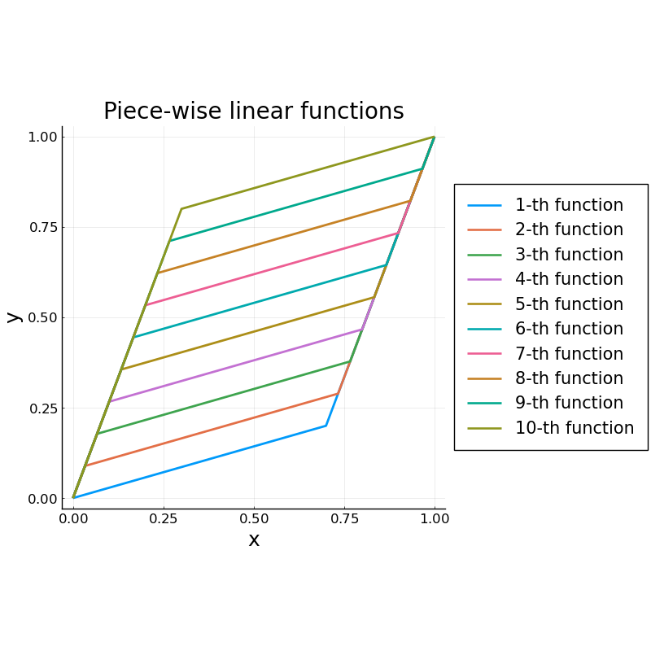

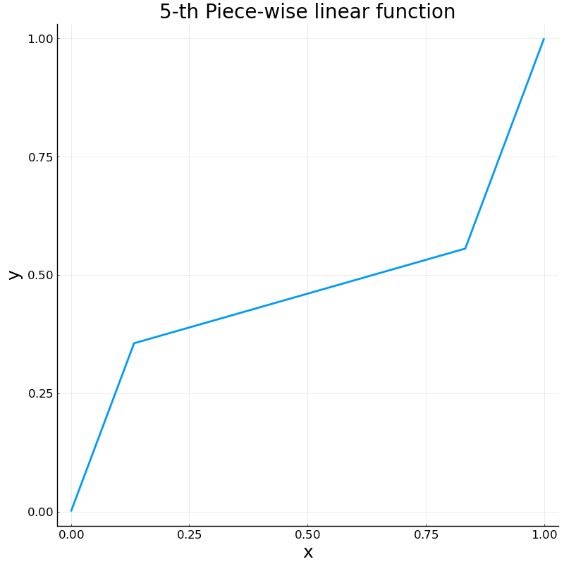

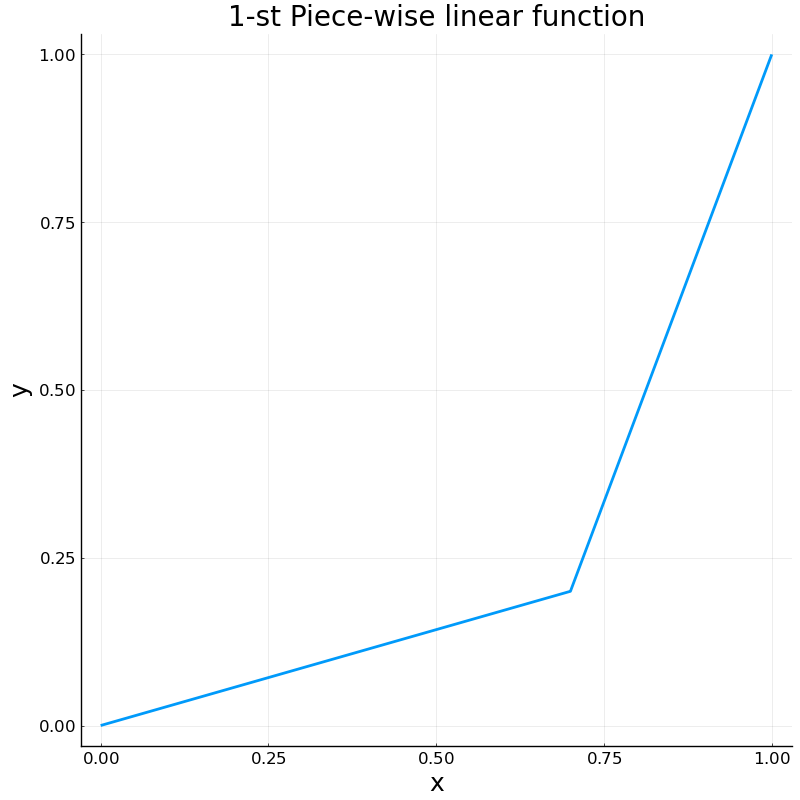

Use `getcompactsigmoidparameters()` to fit the parameters $a$ and $b$ of the logistic-logit function to the flat slope regions for each of the piece-wise linear functions.

```julia
p0 = [0.5; 0.0] # initial guess.
p_lb = [0.1; -5.0] # optimization lower bounds for parameters a and b.
p_ub = [0.6; 5.0] # optimization upper bounds for the
optim_algorithm = :LN_BOBYQA # a local derivative-free algorithm. For other algorithms in NLopt, see https://nlopt.readthedocs.io/en/latest/NLopt_Algorithms/

costfuncs, minxs, rets = IntervalMonoFuncs.getcompactsigmoidparameters(infos; p0 = p0, p_lb = p_lb, p_ub = p_ub, optim_algorithm = optim_algorithm)
qs = collect( tt->IntervalMonoFuncs.evalcompositelogisticprobit(tt, minxs[i][1], minxs[i][2]) for i = 1:length(minxs) )
```

Visualize.

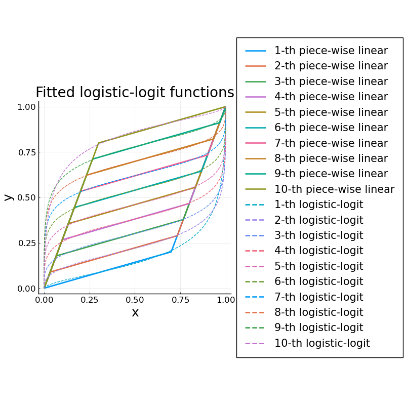

The parameters $a$ and $b$ are stored in `minxs`.

```julia
minxs
```

```
10-element Vector{Vector{Float64}}:
 [0.6, 3.0787570403627242]
 [0.3791779323634944, 3.3455443201508235]
 [0.29826376533251797, 2.833803200501286]
 [0.26484911301357034, 1.8398452043422155]
 [0.25138060494016945, 0.6347582197302831]
 [0.2513806049401704, -0.6347582197302839]
 [0.26484911306309733, -1.8398452042179614]
 [0.29826376525032483, -2.833803201732739]
 [0.37917793236401104, -3.34554432014553]
 [0.6, -3.0787557339313585]
```

The approximate center of the focus range interval for each of the functions are stored in `p_range`.

```julia
p_range
```

```
10-element LinRange{Float64, Int64}:
 0.1,0.188889,0.277778,0.366667,0.455556,…,0.633333,0.722222,0.811111,0.9
```

For example: We see that the $(a,b)$ parameter for the 5-th logistic-logit function is $minxs[5] = (0.25138060494016945,0.6347582197302831)$. It is a logistic-logit function that maps `domain_proportion` of the domain (x) to `range_proportion` of the range (y) that is roughly centered around $0.45555555555555555$.

Application: One can use the $a$ values in `minxs` as interpolation samples to inputs given in `p_range`, and similarly fit another interpolation function for the $b$ values in `minxs`. One can then obtain $(a,b)$ values for any focus range interval centers that are in `[p_range[1], p_range[end]`. One could apply this type of smooth monotone map to encourage variable exploration in a focused region in numerical optimization routines. This is used in NMRCalibrate.jl.

Published from logistic-logit_fit.jmd using Weave.jl v0.10.10 on 2022-04-05.